# **Addition Insights - Companies to Watch Newsletter**

August 19, 2022

## **Apollo**

**Company:** Apollo  
**Country (Operating):** 101 Montgomery Street, Suite 400, San Francisco, CA 94104, United States  
**Founded Date:** January 01, 2015  
**Homepage:** https://apollo.io  
**Current Headcount:** 283  
**Lifetime Funding:** $151,320,000  
**Number of Funding Rounds:** 5  
**Investors:** Alpha Partners, SV Angel, Sand Hill Angels, CRCM Ventures, Hack VC, Mighty Capital, ZhenFund 真格基金, Tribe Capital, Argonautic Ventures, SYNERGIE VENTURES LIMITED, Johnson & Johnson Innovation – JJDC, Pascal Capital, Flight Ventures, Apollo, Velocity Digital, Initialized Capital, Boost VC, Struck Capital, Social Capital, ShangBay Capital, Nexus Venture Partners, Heavybit, NewView Capital, Frankel iCapital Holdings, Bossanova Investimentos, Y Combinator, IA Ventures, SV Tech Ventures, Sequoia Capital  
**Most Recent Funding:** SERIES C - March 03, 2022  
**Sectors:** Launch, Sales / Ads / Marketing / BD, SaaS  
**Description:** Apollo.io is a B2B sales intelligence and engagement platform, trusted by over 160,000 companies and more than one million users globally, from rapidly growing startups to some of the world’s largest enterprises. Apollo.io provides sales teams with easy access to contact data for over 220 million contacts, along with tools to engage with thesecontacts in one single platform. By helping sales professionals find the most accurate contact information and automating the outreach process, Apollo.io turns prospects into customers.

### **Headcount**

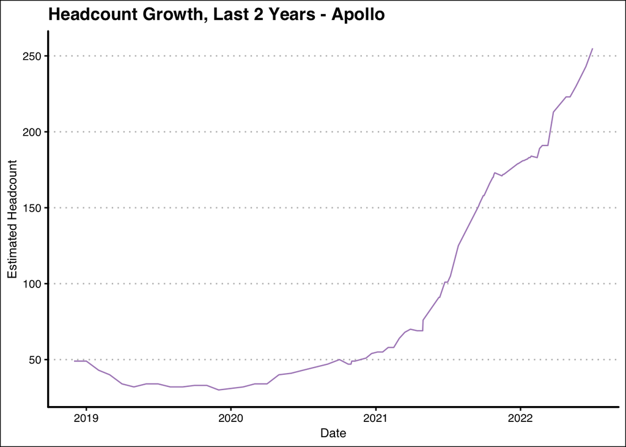

### **Buyer Intent (G2)**

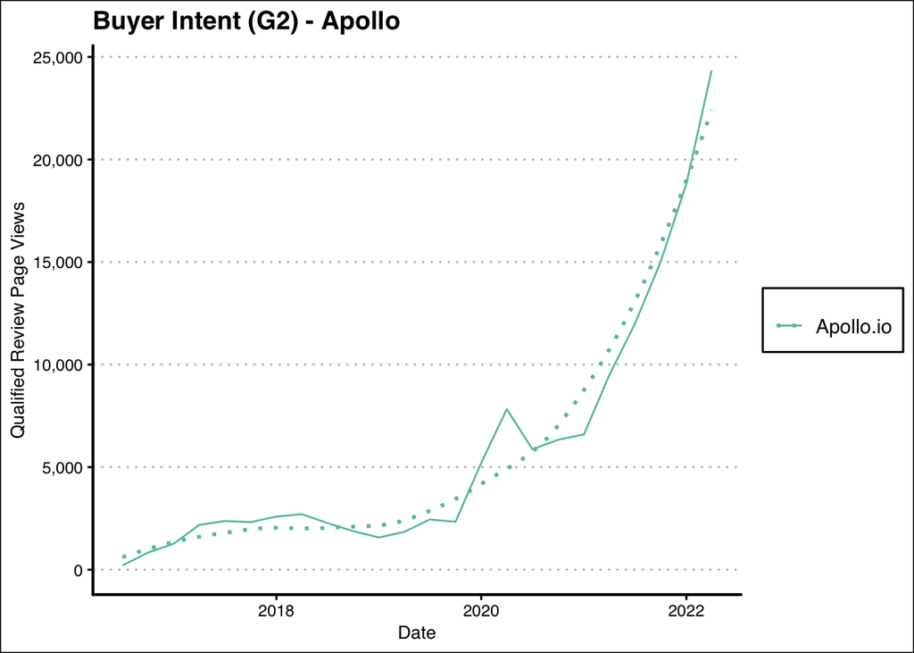

## **Writesonic**

**Company:** Writesonic  
**Country (Operating):** 2261 Market Street, Suit 4608, San Francisco, CA 94114, United States  
**Founded Date:** January 01, 2021  
**Homepage:** https://writesonic.com  
**Current Headcount:** 16  
**Lifetime Funding:** $2,625,000  
**Number of Funding Rounds:** 2  
**Investors:** HOF Capital, Amino Capital, Broom Ventures, Rebel Fund, John Xie, Y Combinator, BluePointe Ventures, Soma Capital, Atlas Pacific Capital  
**Most Recent Funding:** SEED - September 30, 2021  
**Sectors:** Media / News / Entertainment, S21, Sales / Ads / Marketing / BD, Social Networking, AI / ML, SaaS, E-Commerce  
**Description:** Writesonic is an AI-powered writing assistant with a mission to empower everyone in the world to write anything and publish anywhere. It’s like Canva for writing, with tools that simplify the process of creating, editing, and publishing articles, blog posts, ads, landing pages, eCommerce product descriptions, social media posts, and many other forms of content. Our customers love us, as evidenced by the 5000+ 5-star reviews on G2, TrustPilot, and Capterra. Backed by Y Combinator, HOF Capital (investors in Uber, Stripe, Alibaba, UiPath, Klarna), Rebel Fund (team includes founders of Instacart, Reddit, and Cruise), Soma Capital (investors in Deel, Rippling, Razorpay, Lattice, coda, Rappi), Broom Ventures, Amino Capital (investors in Zoom, Webflow, Rippling) and some of the best angels from different industries.

### **Headcount**

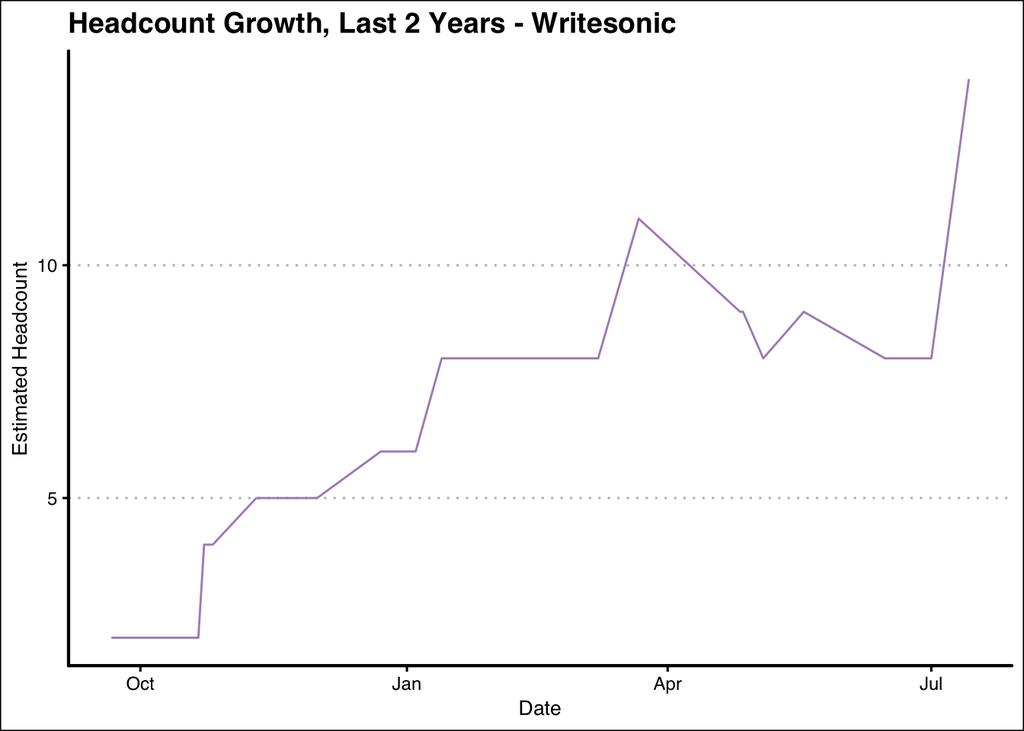

### **Buyer Intent (G2)**

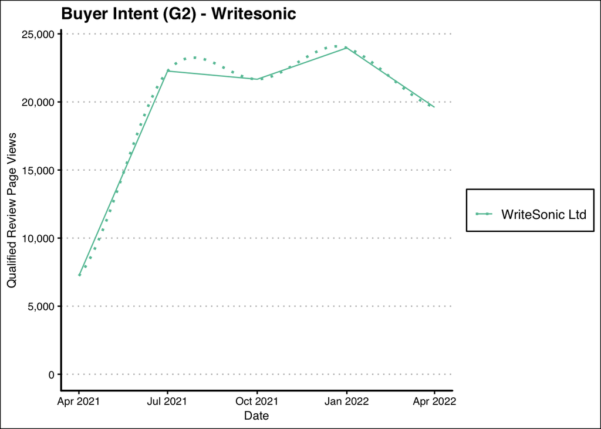

## **Scalenut**

**Company:** Scalenut  
**Country (Operating):** Flat Number- 2803, Tower-F, Ireo Grand Arch, Sector-58, Gurugram, Harayana 122001, India  
**Founded Date:** January 01, 2020  
**Homepage:** https://www.scalenut.com  
**Current Headcount:** 78  
**Lifetime Funding:** $400,000  
**Number of Funding Rounds:** 1  
**Investors:** AngelList India, FirstPrinciples, WhiteHill Ventures, Titan Capital, Abhishek Goyal  
**Most Recent Funding:** SEED - September 15, 2021  
**Sectors:** AI / ML, SaaS  
**Description:** Scalenut is a content intelligence SaaS platform that helps you discover and create the most relevant content for your customers. It uses deep learning and AI to create the best content possible. It is one of the the easiest content creation tool for companies of all sizes. There are no limits to who can use it! Scale with us!

### **Headcount**

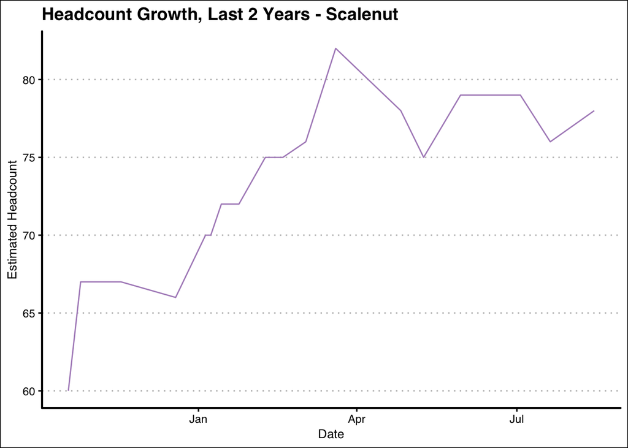

### **Buyer Intent (G2)**

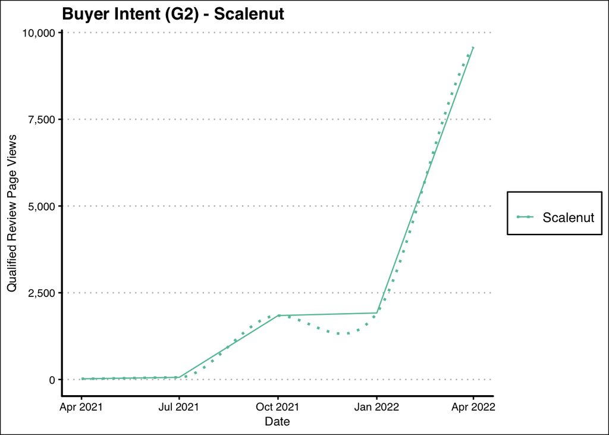

## **Gladly**

**Company:** Gladly  
**Country (Operating):** San Francisco, California, United States  
**Founded Date:** January 01, 2015  
**Homepage:** http://gladly.com  
**Current Headcount:** 168  
**Lifetime Funding:** $113,000,000  
**Number of Funding Rounds:** 6  
**Investors:** SV Angel, DCVC, GGV Capital, New Enterprise Associates (NEA), JetBlue Technology Ventures, Future Fund, Greylock, Glynn Capital  
**Most Recent Funding:** SERIES D - January 29, 2019  
**Sectors:**  
**Description:** Gladly is a Radically Personal Customer Service Platform. Unlike legacy customer service platforms that are case centric, only Gladly is designed with people at the center and uniquely enables a single lifelong customer conversation from voice to modern messaging. Gladly powers some of the most innovative consumer companies like Warby Parker, JOANN, and TUMI to deliver exceptional customer experiences and makes customer service a competitive advantage. Based in San Francisco, Gladly was founded in 2014 and is privately backed by industry leaders including Greylock, GGV Capital, NEA, Glynn Capital, FutureFund, and JetBlue Ventures.

### **Headcount**

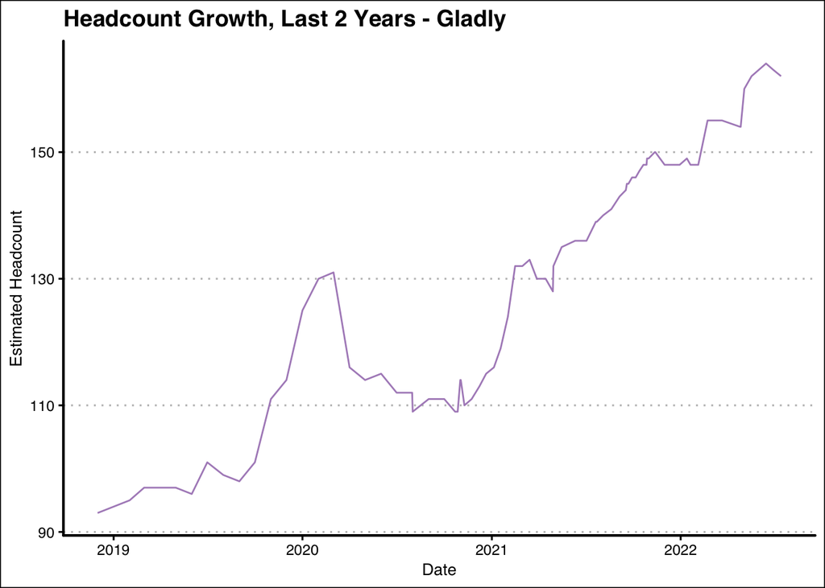

### **Buyer Intent (G2)**

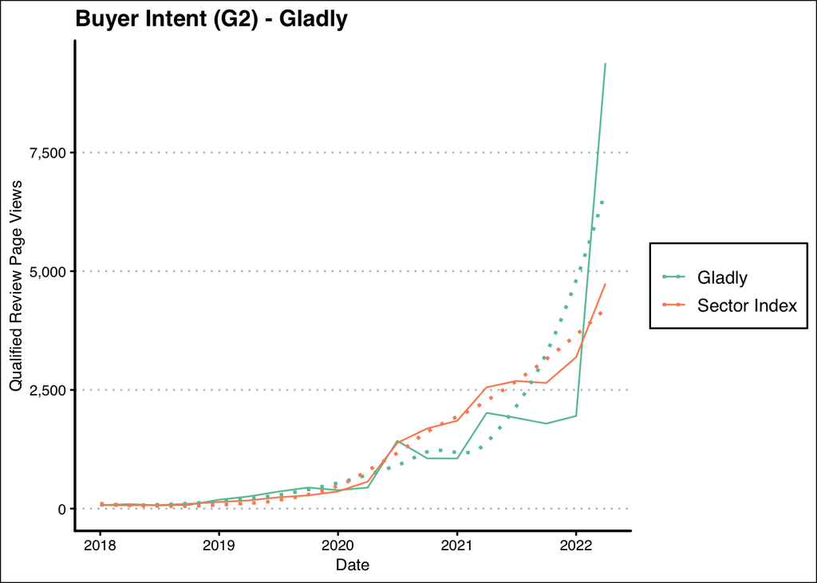

## **Tidio**

**Company:** Tidio  
**Country (Operating):** 160 Spear Street, San Francisco, CA 94105, United States  
**Founded Date:** January 01, 2013  
**Homepage:** https://tidio.com  
**Current Headcount:** 148  
**Lifetime Funding:** $26,834,547  
**Number of Funding Rounds:** 4  
**Investors:** Rafal Brzoska, InCredibles, PeakSpan Capital, Inovo Venture Partners, bValue Fund, Mariusz Fyrstenberg, Rafał Brzoska  
**Most Recent Funding:** SERIES B - May 12, 2022  
**Sectors:**  
**Description:** Tidio is a customer experience tool that helps small businesses serve their clients efficiently. Our flagship product is a live chat app powered by chatbots used by over 510 million unique users around the world. We use our expertise to build products that give our customers autonomy and full ownership of their communication. We want Tidio to be simple and fair, which means easy-to-use tools and transparent pricing. This is only possible because our product reflects the company and the way we work. We trust each other and work with a high degree of autonomy. We are fair and transparent, so that everyone is on the same page. And we are not just avid learners, we are eager to share our expertise with each other. Working at Tidio means having an impact on thousands of companies and millions of their users. But they aren’t the only ones who can grow with us. By joining Tidio, you can grow, too! #GrowWithTidio 🚀

### **Headcount**

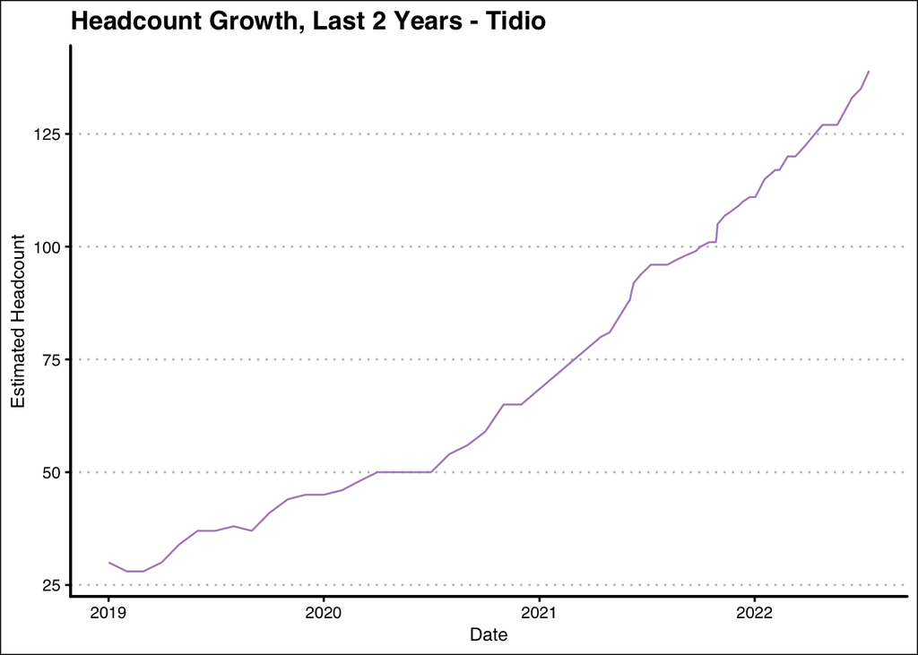

### **Buyer Intent (G2)**

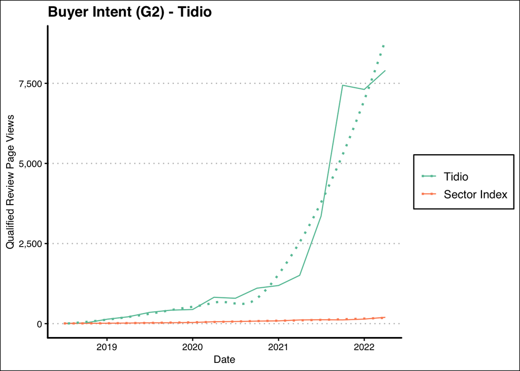

## **Hoxhunt**

**Company:** Hoxhunt  
**Country (Operating):** Porkkalankatu 3, 00180 Helsinki, Finland  
**Founded Date:** January 01, 2016  
**Homepage:** http://hoxhunt.com  
**Current Headcount:** 127  
**Lifetime Funding:** $43,269,235  
**Number of Funding Rounds:** 3  
**Investors:** First Fellow Partners, Icebreaker.vc, Dawn Capital, Level Equity, Risto Siilasmaa  
**Most Recent Funding:** SERIES B - May 31, 2022  
**Sectors:** Security / Encryption Tech, Cybersecurity  
**Description:** Data breaches start with people, so Hoxhunt does too. We combine cognitive automation with the human touch to create individualized adaptive training experiences employees love, and a managed service model enterprises depend on.

### **Headcount**

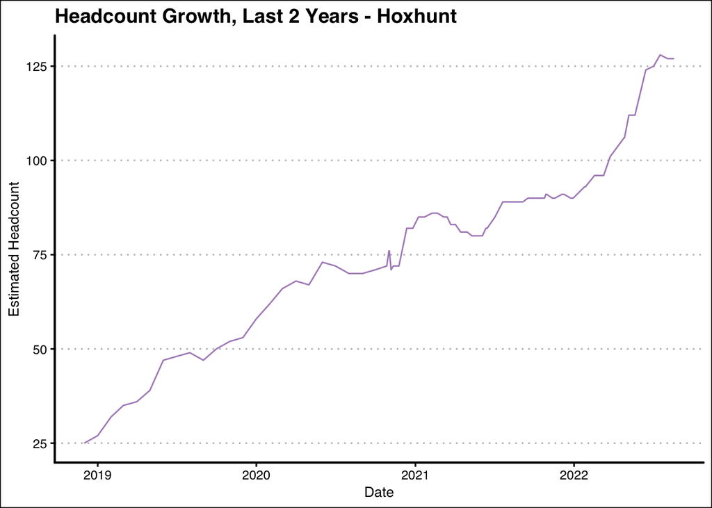

### **Buyer Intent (G2)**

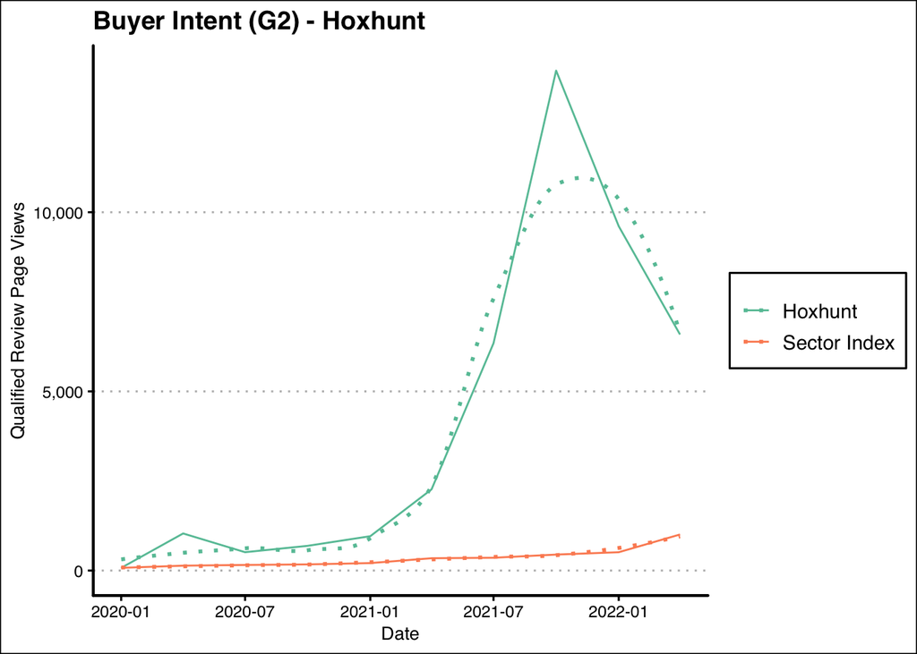

## **Synthesia**

**Company:** Synthesia  
**Country (Operating):** London, England, United Kingdom  
**Founded Date:** January 01, 2009  
**Homepage:** http://synthesia.io  
**Current Headcount:** 117  
**Lifetime Funding:** $66,600,000  
**Number of Funding Rounds:** 6  
**Investors:** Kleiner Perkins, Legacy Knight : Multi-Family Office, LDV Capital, Seedcamp, VAS Ventures, Tiny Supercomputer Investment Company, FirstMark Capital, MMC Ventures, Nigel Morris, S16VC, Christian Bach, GV, Michael Buckley, Mark Cuban, Taavet Hinrikus  
**Most Recent Funding:** SERIES B - December 08, 2021  
**Sectors:** AI / ML  
**Description:** Create professional AI videos from text in 60+ languages. Synthesia saves you money, time and quite some nerves. Perfect for building training and instructional videos 👉 Trusted by Accenture, Nike, BBC, Google, Amazon and more.

### **Headcount**

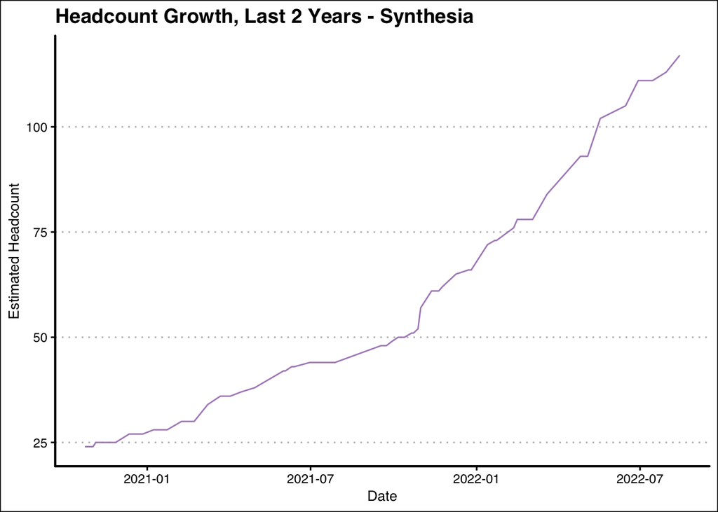

### **Buyer Intent (G2)**

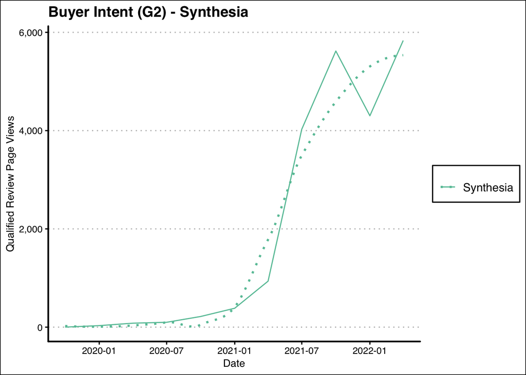

## **Sanity.io**

**Company:** Sanity.io  
**Country (Operating):** 2345 Yale Street, Floor 1, Palo Alto, CA 94306, United States  
**Founded Date:** January 01, 2016  
**Homepage:** https://sanity.io  
**Current Headcount:** 107  
**Lifetime Funding:** $51,800,000  
**Number of Funding Rounds:** 7  
**Investors:** Evan Williams, Spearhead, Jon Dahl, Google, The Nordic Web Ventures, Monochrome Capital, Heavybit, Shopify, Grotmol Solutions AS, ICONIQ Capital, Bakken & Bæck, Edvard Engesaeth, Adam Gross, Threshold Ventures, Christian Bach, Rauch Guillermo, Alliance Venture, ICONIQ Growth, Lead Edge Capital, Edvard Engesæth MD, Mathias Biilmann Christensen, Trond Riiber Knudsen, Thomas C. Holst, Stephanie Friedman, Wilhelm Joys Andersen, Guillermo Rauch, Ohad Eder-Pressman, Edvard Engesæth, Anne Worsoe, Peter Secor, Ev Williams, NULL  
**Most Recent Funding:** LATER STAGE VC - June 29, 2022  
**Sectors:** Dev Tools, OSS, SaaS  
**Description:**

### **Headcount**

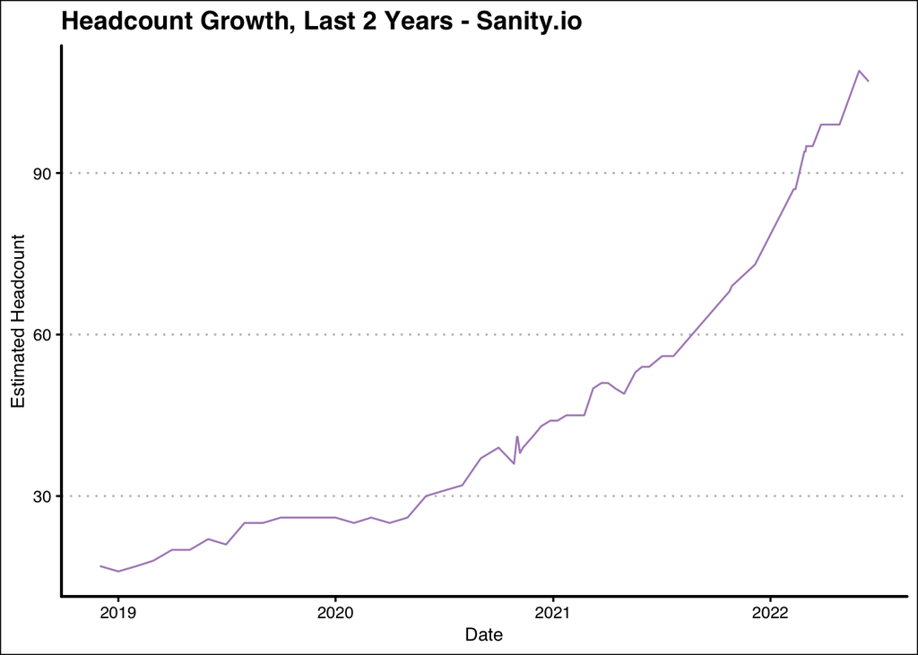

### **Buyer Intent (G2)**

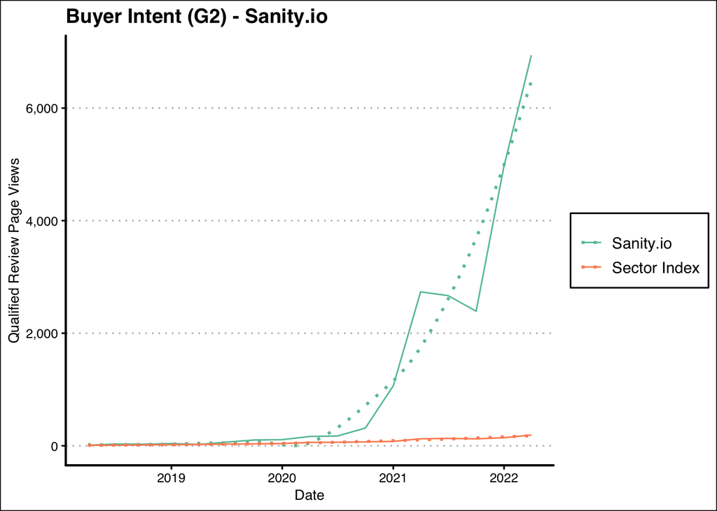

## **Storyblok**

**Company:** Storyblok  
**Country (Operating):** Peter-Behrens-Platz 2, Linz, 4020, Austria  
**Founded Date:** January 01, 2015  
**Homepage:** http://storyblok.com  
**Current Headcount:** 173  
**Lifetime Funding:** $58,000,000  
**Number of Funding Rounds:** 4  
**Investors:** 3VC, Founders Factory, Mubadala Capital-Ventures, Mubadala, HV Capital, Mubadala Capital | Ventures Europe, tech2b Inkubator GmbH, firstminute capital  
**Most Recent Funding:** SERIES B - May 17, 2022  
**Sectors:** IoT, Dev Tools, SaaS, AR / VR  
**Description:** Storyblok is a Headless Content Management System that provides developers with all the flexibility they need to build reliable and fast websites whilst giving content creators with no coding skills the ability to edit content independently of the developer. Thanks to the headless approach your content can not only be used for one website, which is the case if you use a monolithic CMS like WordPress. Storyblok empowers you to use your content on iOS and Android apps, as well as any other platform of choice (IoT, smartwatch, AR/VR) through Application Programming Interfaces (“APIs”).

### **Headcount**

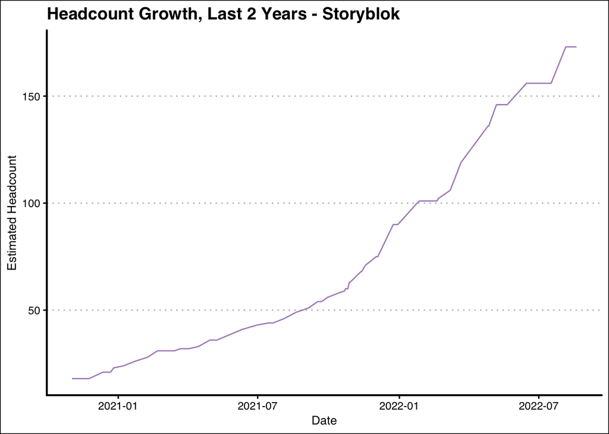

### **Buyer Intent (G2)**

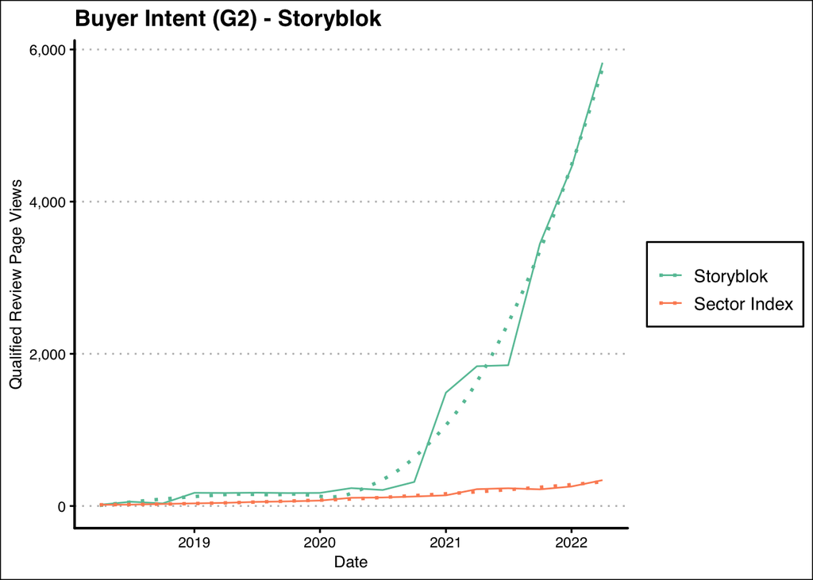

## **Leapsome**

**Company:** Leapsome  
**Country (Operating):** Dunckerstrasse 3, 10437 Berlin, Germany  
**Founded Date:** January 01, 2016  
**Homepage:** http://leapsome.com  
**Current Headcount:** 109  
**Lifetime Funding:** $60,000,000  
**Number of Funding Rounds:** 1  
**Investors:** CREANDUM, Insight Partners, Visionaries Club  
**Most Recent Funding:** SERIES A - March 24, 2022  
**Sectors:** SaaS, Staffing / Recruiting / HR  
**Description:**

### **Headcount**

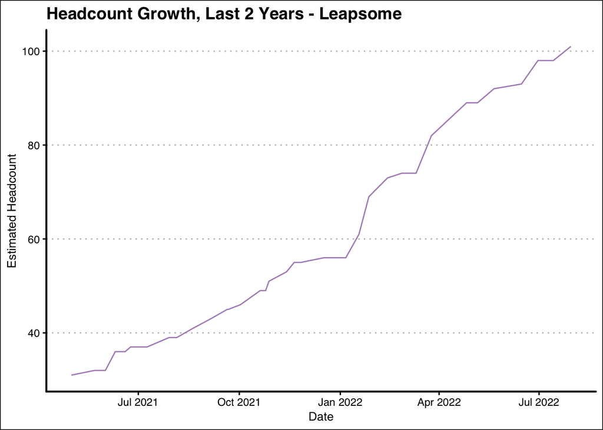

### **Buyer Intent (G2)**

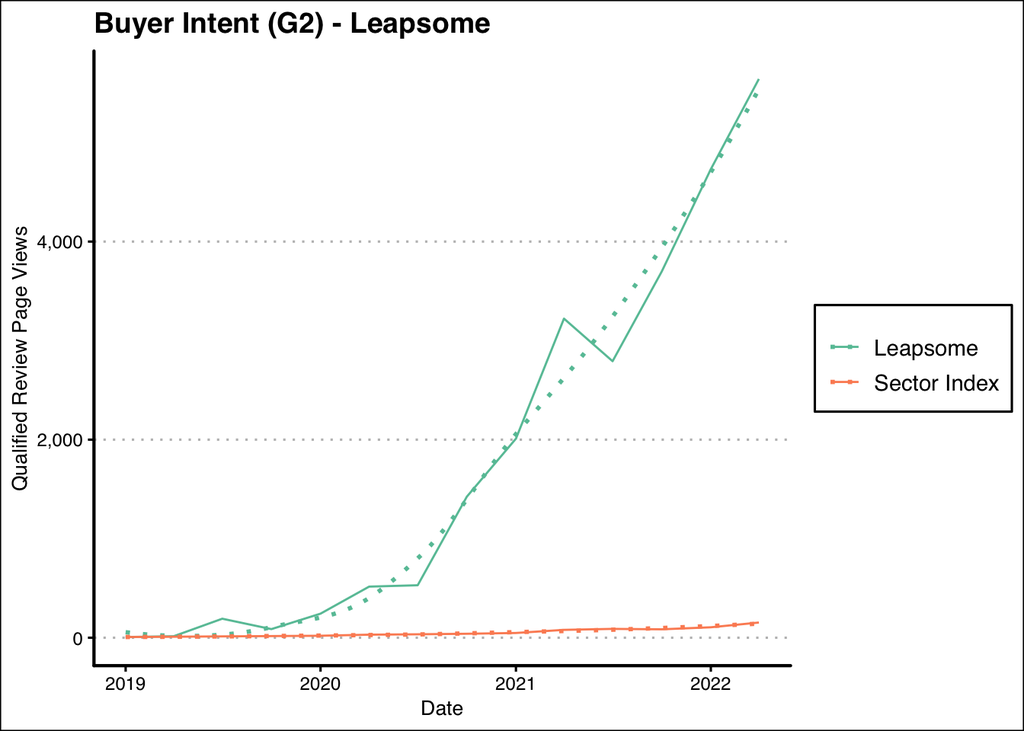